# Human Activity Recognition (HAR) Classification Course Project

Alexandr Popov

## Introduction

The given data consist of data from accelerometers on the belt, forearm, arm, and dumbell of 6 participants. The aim of this project is to predict manner in which they did exercise. More information on used data set and original study can be found in [1,2].

## Data Preparation and Partitioning

First we will load training and testing data sets:

```r
# load training data set
train_ds = read.csv("pml-training.csv",
                    na.strings="NA",
                    stringsAsFactors = FALSE)

# load test data set
test_ds = read.csv("pml-testing.csv")
```

In order to get cleaner data the non-numeric variables and near zero values were removed from the data sets:

```r
## remove all non-numeric values from data set
train_ds <- train_ds[, which(as.numeric(colSums(is.na(train_ds)))==0)]
test_ds <- test_ds[, which(as.numeric(colSums(is.na(test_ds)))==0)]

## remove near zero values from data set
train_ds <- train_ds[, nearZeroVar(train_ds, saveMetrics = TRUE)$nzv==FALSE]
test_ds <-test_ds[, nearZeroVar(test_ds, saveMetrics = TRUE)$nzv==FALSE]
train_ds$classe <- factor(train_ds$classe)
```

```r
## remove meaningless variables from the data sets (e.g. "X", "user name")
train_ds_clean <- train_ds[,-(1:7)]
test_ds_clean <- test_ds[,-(1:7)]
```

We will select 60% of samples from the original training set for building the model, and other 40% will be used for cross-validation.

```r
set.seed(333)
inTrain = createDataPartition(y = train_ds_clean$classe, p=0.6, list = FALSE)

training = train_ds_clean[inTrain, ]
testing = train_ds_clean[-inTrain, ]
```

## Building Model

To build data model we will use Random Forest classification algorithm. In order to select optimal model tuning parameters 3-fold cross-validation was used.

```r
# build model with random forest (3-fold cv)
newTC <- trainControl(method="cv", number=3, verboseIter=T)
model <- train(classe ~ ., data=training, method="rf",
         trControl=newTC)
```

The final model can be obtained by:

```r
# obtain final model
model$finalModel
```

```
##
## Call:
##  randomForest(x = x, y = y, mtry = param$mtry)
##                Type of random forest: classification
##                      Number of trees: 500
## No. of variables tried at each split: 26
##
##         OOB estimate of  error rate: 0.9%
## Confusion matrix:
##      A    B    C    D    E class.error
## A 3343    3    1    0    1 0.001493429
## B   24 2244    8    2    1 0.015357613
## C    0   14 2033    7    0 0.010223953
## D    0    1   29 1898    2 0.016580311
## E    0    0    3   10 2152 0.006004619
```

According to output there is 500 trees and 26 variables at each split.

## Cross-Validation (predicting pseudo out-of-sample)

Now we can use fitted model to predict **classe** within test data set

```r
# predict classe with obtained model
prediction <- predict(model, newdata=testing)

# print confusion matrix
confusionMatrix(testing$classe, prediction)
```

```
## Confusion Matrix and Statistics
##
##           Reference
## Prediction    A    B    C    D    E
##          A 2230    1    1    0    0
##          B   16 1494    6    1    1
##          C    0   14 1351    3    0
##          D    0    0   10 1275    1
##          E    0    0    0    3 1439
##
## Overall Statistics
##
##                Accuracy : 0.9927
##                  95% CI : (0.9906, 0.9945)
##     No Information Rate : 0.2863
##     P-Value [Acc > NIR] : < 2.2e-16
##
##                   Kappa : 0.9908
##  Mcnemar's Test P-Value : NA
##
## Statistics by Class:
##
##                      Class: A Class: B Class: C Class: D Class: E
## Sensitivity            0.9929   0.9901   0.9876   0.9945   0.9986
## Specificity            0.9996   0.9962   0.9974   0.9983   0.9995
## Pos Pred Value         0.9991   0.9842   0.9876   0.9914   0.9979
## Neg Pred Value         0.9971   0.9976   0.9974   0.9989   0.9997
## Prevalence             0.2863   0.1923   0.1744   0.1634   0.1837
## Detection Rate         0.2842   0.1904   0.1722   0.1625   0.1834
## Detection Prevalence   0.2845   0.1935   0.1744   0.1639   0.1838
## Balanced Accuracy      0.9963   0.9931   0.9925   0.9964   0.9991
```

Obtained accuracy is 99.3%, which indicates that pseudo out-of-sample error is 0.7%. With these results, we are confident that our model is ready to classify new data without having to fine-tune the classification algorithm.

## Testing (prediction out-of-sample)

The out-of-sample data will be predicted from **pml-testing.csv**. Prediction output is generated in separate text files. Accuracy verification was performed within the second part of assignment, with 20/20 samples classified correctly.

```r
pml_write_files = function(x) {
  n = length(x)
  for (i in 1:n) {
    filename = paste0("problem_id_", i, ".txt")
    write.table(x[i], file=filename, quote=FALSE, row.names=FALSE, col.names=FALSE)
  }
}

pred = predict(model, test_ds_clean)
pml_write_files(pred)
```

## Conclusion

The Random Forest classification algorithms was selected to build model. It was founded that the accuracy of this algorithm is acceptable to classify new data from test data set. Accuracy verification was performed in “Course Project: Submission”.

## Appendix

Additionaly we can compute importance of each variable for the model. The r code is:

```r
var_imp = varImp(model$finalModel)
var_imp$var_name<-rownames(var_imp)
var_imp = as.data.frame(var_imp[with(var_imp, order(var_imp$Overall, decreasing=TRUE)), ])
rownames(var_imp) <- NULL
print(var_imp)
```

```
##      Overall             var_name
## 1  864.33627             yaw_belt
## 2  804.03147        pitch_forearm
## 3  622.07487           pitch_belt
## 4  615.48816    magnet_dumbbell_z
## 5  495.61564    magnet_dumbbell_y
## 6  441.49971         roll_forearm
## 7  359.06201         accel_belt_z
## 8  288.82161         gyros_belt_z
## 9  283.85669        roll_dumbbell
## 10 274.47622        magnet_belt_y
## 11 269.76483    magnet_dumbbell_x
## 12 261.52578        magnet_belt_z
## 13 259.69520     accel_dumbbell_y
## 14 210.23274      accel_forearm_x
```

[output cut: 37 more lines]

It can be seen that the mos important variables are “yaw_belt” and “pitch forearm”. Following plot was build to explore possible correlation of two most important variables

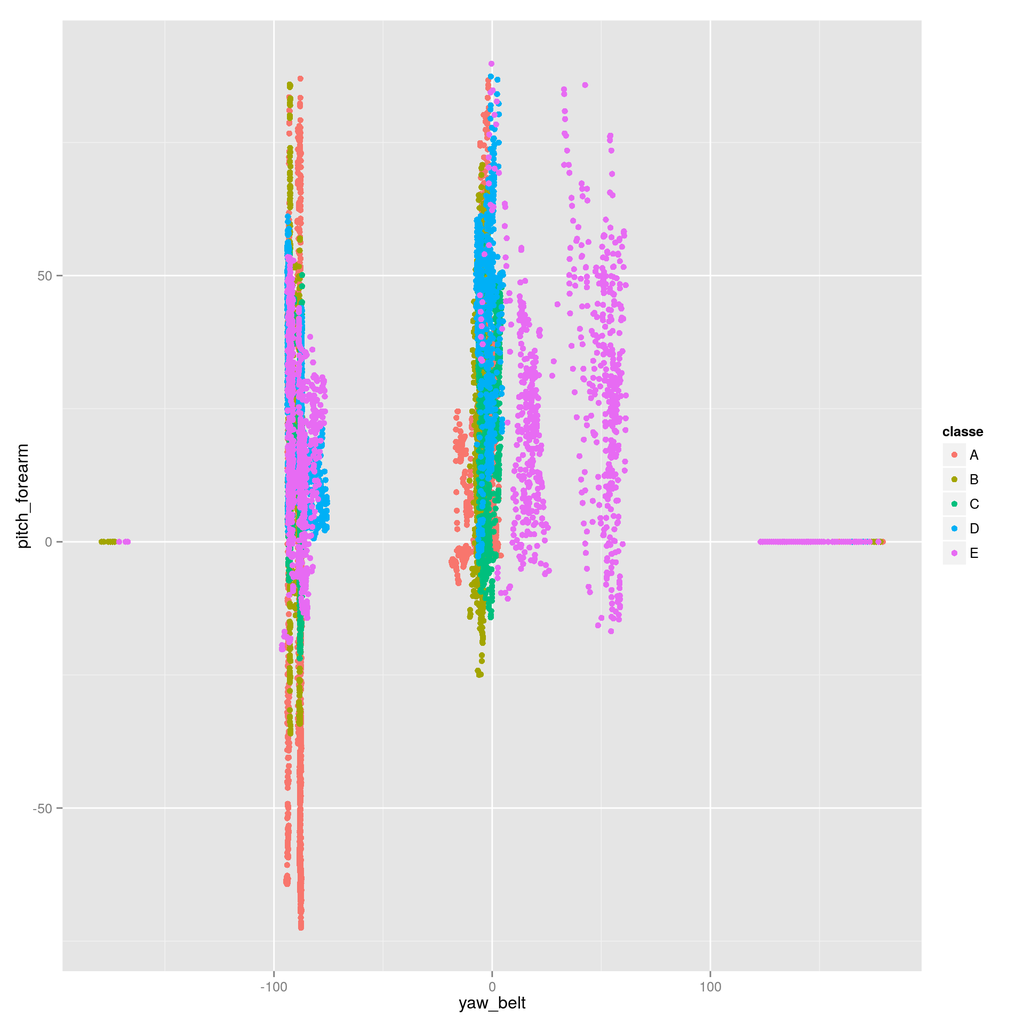

## Bibliography

[1] Velloso, E.; Bulling, A.; Gellersen, H.; Ugulino, W.; Fuks, H. Qualitative Activity Recognition of Weight Lifting Exercises. Proceedings of 4th International Conference in Cooperation with SIGCHI (Augmented Human ’13) . Stuttgart, Germany: ACM SIGCHI, 2013.

[2] http://groupware.les.inf.puc-rio.br/har#weight_lifting_exercises#ixzz3awXcRGJZ